# Risk Factor Analysis

## Outcome Variable

**Outcome Variable:** ever_swasted

## Predictor Variables

**Intervention Variable:** perdiar6

**Adjustment Set:**

- arm
- sex
- W_mage
- meducyrs
- feducyrs
- hhwealth_quart
- hfoodsec
- W_mhtcm
- W_mwtkg
- W_mbmi
- W_birthwt
- W_birthlen
- W_nrooms
- month
- brthmon
- impfloor
- impsan
- safeh20
- delta_W_mage
- delta_meducyrs
- delta_feducyrs
- delta_hhwealth_quart
- delta_hfoodsec
- delta_W_mhtcm
- delta_W_mwtkg
- delta_W_mbmi
- delta_W_birthwt
- delta_W_birthlen
- delta_W_nrooms
- delta_month
- delta_brthmon
- delta_impfloor
- delta_impsan
- delta_safeh20

## Stratifying Variables

The analysis was stratified on these variable(s):

- agecat
- studyid
- country

## Data Summary

| agecat | studyid | country | perdiar6 | ever_swasted | n_cell | n |
| --- | --- | --- | --- | --- | --- | --- |
| 0-24 months (no birth wast) | ki0047075b-MAL-ED | BANGLADESH | 0% | 0 | 80 | 263 |
| 0-24 months (no birth wast) | ki0047075b-MAL-ED | BANGLADESH | 0% | 1 | 5 | 263 |
| 0-24 months (no birth wast) | ki0047075b-MAL-ED | BANGLADESH | (0%, 5%] | 0 | 93 | 263 |
| 0-24 months (no birth wast) | ki0047075b-MAL-ED | BANGLADESH | (0%, 5%] | 1 | 5 | 263 |
| 0-24 months (no birth wast) | ki0047075b-MAL-ED | BANGLADESH | >5% | 0 | 78 | 263 |
| 0-24 months (no birth wast) | ki0047075b-MAL-ED | BANGLADESH | >5% | 1 | 2 | 263 |
| 0-24 months (no birth wast) | ki0047075b-MAL-ED | BRAZIL | 0% | 0 | 212 | 233 |
| 0-24 months (no birth wast) | ki0047075b-MAL-ED | BRAZIL | 0% | 1 | 4 | 233 |
| 0-24 months (no birth wast) | ki0047075b-MAL-ED | BRAZIL | (0%, 5%] | 0 | 15 | 233 |
| 0-24 months (no birth wast) | ki0047075b-MAL-ED | BRAZIL | (0%, 5%] | 1 | 0 | 233 |
| 0-24 months (no birth wast) | ki0047075b-MAL-ED | BRAZIL | >5% | 0 | 2 | 233 |
| 0-24 months (no birth wast) | ki0047075b-MAL-ED | BRAZIL | >5% | 1 | 0 | 233 |
| 0-24 months (no birth wast) | ki0047075b-MAL-ED | INDIA | 0% | 0 | 53 | 246 |
| 0-24 months (no birth wast) | ki0047075b-MAL-ED | INDIA | 0% | 1 | 6 | 246 |
| 0-24 months (no birth wast) | ki0047075b-MAL-ED | INDIA | (0%, 5%] | 0 | 124 | 246 |
| 0-24 months (no birth wast) | ki0047075b-MAL-ED | INDIA | (0%, 5%] | 1 | 4 | 246 |
| 0-24 months (no birth wast) | ki0047075b-MAL-ED | INDIA | >5% | 0 | 56 | 246 |
| 0-24 months (no birth wast) | ki0047075b-MAL-ED | INDIA | >5% | 1 | 3 | 246 |
| 0-24 months (no birth wast) | ki0047075b-MAL-ED | NEPAL | 0% | 0 | 81 | 239 |
| 0-24 months (no birth wast) | ki0047075b-MAL-ED | NEPAL | 0% | 1 | 2 | 239 |
| 0-24 months (no birth wast) | ki0047075b-MAL-ED | NEPAL | (0%, 5%] | 0 | 75 | 239 |
| 0-24 months (no birth wast) | ki0047075b-MAL-ED | NEPAL | (0%, 5%] | 1 | 1 | 239 |
| 0-24 months (no birth wast) | ki0047075b-MAL-ED | NEPAL | >5% | 0 | 80 | 239 |
| 0-24 months (no birth wast) | ki0047075b-MAL-ED | NEPAL | >5% | 1 | 0 | 239 |
| 0-24 months (no birth wast) | ki0047075b-MAL-ED | PERU | 0% | 0 | 88 | 302 |
| 0-24 months (no birth wast) | ki0047075b-MAL-ED | PERU | 0% | 1 | 1 | 302 |
| 0-24 months (no birth wast) | ki0047075b-MAL-ED | PERU | (0%, 5%] | 0 | 92 | 302 |
| 0-24 months (no birth wast) | ki0047075b-MAL-ED | PERU | (0%, 5%] | 1 | 1 | 302 |
| 0-24 months (no birth wast) | ki0047075b-MAL-ED | PERU | >5% | 0 | 118 | 302 |
| 0-24 months (no birth wast) | ki0047075b-MAL-ED | PERU | >5% | 1 | 2 | 302 |

[output cut: 204 more lines]

The following strata were considered:

- agecat: 0-24 months (no birth wast), studyid: ki0047075b-MAL-ED, country: BANGLADESH
- agecat: 0-24 months (no birth wast), studyid: ki0047075b-MAL-ED, country: BRAZIL
- agecat: 0-24 months (no birth wast), studyid: ki0047075b-MAL-ED, country: INDIA
- agecat: 0-24 months (no birth wast), studyid: ki0047075b-MAL-ED, country: NEPAL
- agecat: 0-24 months (no birth wast), studyid: ki0047075b-MAL-ED, country: PERU
- agecat: 0-24 months (no birth wast), studyid: ki0047075b-MAL-ED, country: SOUTH AFRICA
- agecat: 0-24 months (no birth wast), studyid: ki0047075b-MAL-ED, country: TANZANIA, UNITED REPUBLIC OF
- agecat: 0-24 months (no birth wast), studyid: ki1000109-EE, country: PAKISTAN
- agecat: 0-24 months (no birth wast), studyid: ki1017093-NIH-Birth, country: BANGLADESH
- agecat: 0-24 months (no birth wast), studyid: ki1017093b-PROVIDE, country: BANGLADESH
- agecat: 0-24 months (no birth wast), studyid: ki1017093c-NIH-Crypto, country: BANGLADESH
- agecat: 0-24 months (no birth wast), studyid: ki1114097-CMIN, country: BANGLADESH
- agecat: 0-24 months (no birth wast), studyid: ki1114097-CONTENT, country: PERU
- agecat: 0-6 months (no birth wast), studyid: ki0047075b-MAL-ED, country: BANGLADESH
- agecat: 0-6 months (no birth wast), studyid: ki0047075b-MAL-ED, country: BRAZIL
- agecat: 0-6 months (no birth wast), studyid: ki0047075b-MAL-ED, country: INDIA
- agecat: 0-6 months (no birth wast), studyid: ki0047075b-MAL-ED, country: NEPAL
- agecat: 0-6 months (no birth wast), studyid: ki0047075b-MAL-ED, country: PERU
- agecat: 0-6 months (no birth wast), studyid: ki0047075b-MAL-ED, country: SOUTH AFRICA
- agecat: 0-6 months (no birth wast), studyid: ki0047075b-MAL-ED, country: TANZANIA, UNITED REPUBLIC OF
- agecat: 0-6 months (no birth wast), studyid: ki1000109-EE, country: PAKISTAN
- agecat: 0-6 months (no birth wast), studyid: ki1017093-NIH-Birth, country: BANGLADESH
- agecat: 0-6 months (no birth wast), studyid: ki1017093b-PROVIDE, country: BANGLADESH
- agecat: 0-6 months (no birth wast), studyid: ki1017093c-NIH-Crypto, country: BANGLADESH
- agecat: 0-6 months (no birth wast), studyid: ki1114097-CMIN, country: BANGLADESH
- agecat: 0-6 months (no birth wast), studyid: ki1114097-CONTENT, country: PERU
- agecat: 6-24 months, studyid: ki0047075b-MAL-ED, country: BANGLADESH
- agecat: 6-24 months, studyid: ki0047075b-MAL-ED, country: BRAZIL
- agecat: 6-24 months, studyid: ki0047075b-MAL-ED, country: INDIA
- agecat: 6-24 months, studyid: ki0047075b-MAL-ED, country: NEPAL
- agecat: 6-24 months, studyid: ki0047075b-MAL-ED, country: PERU
- agecat: 6-24 months, studyid: ki0047075b-MAL-ED, country: SOUTH AFRICA
- agecat: 6-24 months, studyid: ki0047075b-MAL-ED, country: TANZANIA, UNITED REPUBLIC OF
- agecat: 6-24 months, studyid: ki1000109-EE, country: PAKISTAN
- agecat: 6-24 months, studyid: ki1017093-NIH-Birth, country: BANGLADESH
- agecat: 6-24 months, studyid: ki1017093b-PROVIDE, country: BANGLADESH
- agecat: 6-24 months, studyid: ki1017093c-NIH-Crypto, country: BANGLADESH
- agecat: 6-24 months, studyid: ki1114097-CMIN, country: BANGLADESH
- agecat: 6-24 months, studyid: ki1114097-CONTENT, country: PERU

### Dropped Strata

Some strata were dropped due to rare outcomes:

- agecat: 0-24 months (no birth wast), studyid: ki0047075b-MAL-ED, country: BANGLADESH
- agecat: 0-24 months (no birth wast), studyid: ki0047075b-MAL-ED, country: BRAZIL
- agecat: 0-24 months (no birth wast), studyid: ki0047075b-MAL-ED, country: INDIA
- agecat: 0-24 months (no birth wast), studyid: ki0047075b-MAL-ED, country: NEPAL
- agecat: 0-24 months (no birth wast), studyid: ki0047075b-MAL-ED, country: PERU
- agecat: 0-24 months (no birth wast), studyid: ki0047075b-MAL-ED, country: SOUTH AFRICA
- agecat: 0-24 months (no birth wast), studyid: ki0047075b-MAL-ED, country: TANZANIA, UNITED REPUBLIC OF
- agecat: 0-24 months (no birth wast), studyid: ki1000109-EE, country: PAKISTAN
- agecat: 0-24 months (no birth wast), studyid: ki1017093b-PROVIDE, country: BANGLADESH
- agecat: 0-24 months (no birth wast), studyid: ki1017093c-NIH-Crypto, country: BANGLADESH
- agecat: 0-24 months (no birth wast), studyid: ki1114097-CONTENT, country: PERU
- agecat: 0-6 months (no birth wast), studyid: ki0047075b-MAL-ED, country: BANGLADESH
- agecat: 0-6 months (no birth wast), studyid: ki0047075b-MAL-ED, country: BRAZIL
- agecat: 0-6 months (no birth wast), studyid: ki0047075b-MAL-ED, country: INDIA
- agecat: 0-6 months (no birth wast), studyid: ki0047075b-MAL-ED, country: NEPAL
- agecat: 0-6 months (no birth wast), studyid: ki0047075b-MAL-ED, country: PERU
- agecat: 0-6 months (no birth wast), studyid: ki0047075b-MAL-ED, country: SOUTH AFRICA
- agecat: 0-6 months (no birth wast), studyid: ki0047075b-MAL-ED, country: TANZANIA, UNITED REPUBLIC OF
- agecat: 0-6 months (no birth wast), studyid: ki1000109-EE, country: PAKISTAN
- agecat: 0-6 months (no birth wast), studyid: ki1017093-NIH-Birth, country: BANGLADESH
- agecat: 0-6 months (no birth wast), studyid: ki1017093b-PROVIDE, country: BANGLADESH
- agecat: 0-6 months (no birth wast), studyid: ki1017093c-NIH-Crypto, country: BANGLADESH
- agecat: 0-6 months (no birth wast), studyid: ki1114097-CMIN, country: BANGLADESH
- agecat: 0-6 months (no birth wast), studyid: ki1114097-CONTENT, country: PERU
- agecat: 6-24 months, studyid: ki0047075b-MAL-ED, country: BANGLADESH
- agecat: 6-24 months, studyid: ki0047075b-MAL-ED, country: BRAZIL
- agecat: 6-24 months, studyid: ki0047075b-MAL-ED, country: INDIA
- agecat: 6-24 months, studyid: ki0047075b-MAL-ED, country: NEPAL
- agecat: 6-24 months, studyid: ki0047075b-MAL-ED, country: PERU
- agecat: 6-24 months, studyid: ki0047075b-MAL-ED, country: SOUTH AFRICA
- agecat: 6-24 months, studyid: ki0047075b-MAL-ED, country: TANZANIA, UNITED REPUBLIC OF
- agecat: 6-24 months, studyid: ki1000109-EE, country: PAKISTAN
- agecat: 6-24 months, studyid: ki1017093b-PROVIDE, country: BANGLADESH
- agecat: 6-24 months, studyid: ki1017093c-NIH-Crypto, country: BANGLADESH
- agecat: 6-24 months, studyid: ki1114097-CONTENT, country: PERU

## Methods Detail

We’re interested in the causal parameters $E[Y_a]$ for all values of $a \in \mathcal{A}$. These parameters represent the mean outcome if, possibly contrary to fact, we intervened to set all units to have $A=a$. Under the randomization and positivity assumptions, these are identified by the statistical parameters $\psi_a=E_W[E_{Y|A,W}(Y|A=a,W)]$. In addition, we’re interested in the mean of $Y$, $E[Y]$ under no intervention (the observed mean). We will estimate these parameters by using SuperLearner to fit the relevant likelihood factors – $E_{Y|A,W}(Y|A=a,W)$ and $p(A=a|W)$, and then updating our likelihood fit using a joint TMLE.

For unadjusted analyses ($W=\{\}$), initial likelihoods were estimated using Lrnr_glm to estimate the simple $E(Y|A)$ and Lrnr_mean to estimate $p(A)$. For adjusted analyses, a small library containing Lrnr_glmnet, Lrnr_xgboost, and Lrnr_mean was used.

Having estimated these parameters, we will then use the delta method to estimate relative risks and attributable risks relative to a prespecified baseline level of $A$.

# Results Detail

## Results Plots

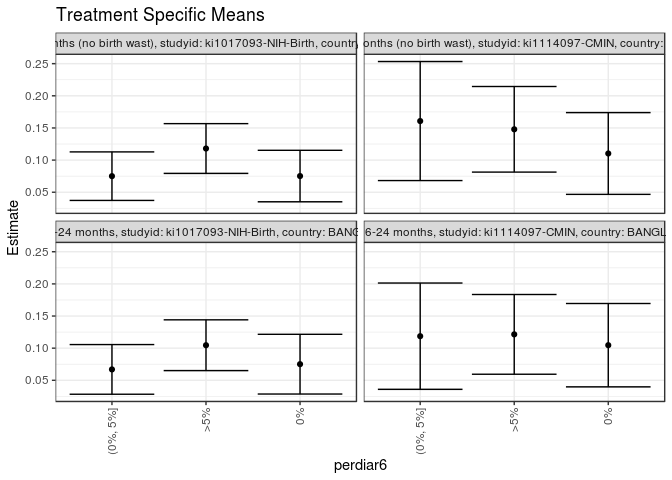

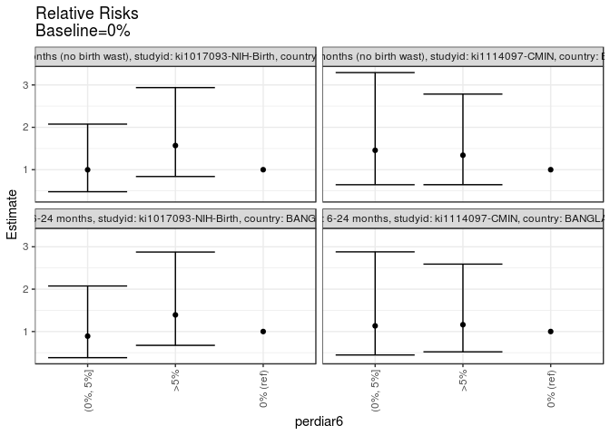

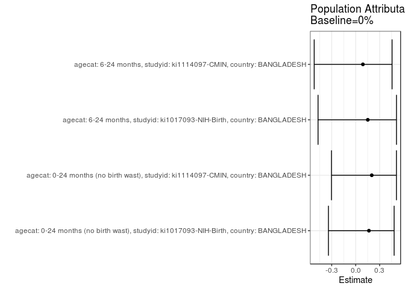

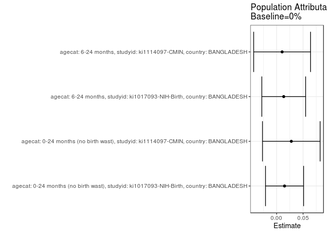

## Results Table

### Parameter: TSM

| agecat | studyid | country | intervention_level | baseline_level | estimate | ci_lower | ci_upper |
| --- | --- | --- | --- | --- | --- | --- | --- |
| 0-24 months (no birth wast) | ki1017093-NIH-Birth | BANGLADESH | 0% | NA | 0.0751804 | 0.0351483 | 0.1152124 |
| 0-24 months (no birth wast) | ki1017093-NIH-Birth | BANGLADESH | (0%, 5%] | NA | 0.0750202 | 0.0372610 | 0.1127794 |
| 0-24 months (no birth wast) | ki1017093-NIH-Birth | BANGLADESH | >5% | NA | 0.1180122 | 0.0793057 | 0.1567187 |
| 0-24 months (no birth wast) | ki1114097-CMIN | BANGLADESH | 0% | NA | 0.1102740 | 0.0466597 | 0.1738883 |
| 0-24 months (no birth wast) | ki1114097-CMIN | BANGLADESH | (0%, 5%] | NA | 0.1607268 | 0.0681424 | 0.2533111 |
| 0-24 months (no birth wast) | ki1114097-CMIN | BANGLADESH | >5% | NA | 0.1478937 | 0.0813372 | 0.2144502 |
| 6-24 months | ki1017093-NIH-Birth | BANGLADESH | 0% | NA | 0.0751310 | 0.0286661 | 0.1215959 |
| 6-24 months | ki1017093-NIH-Birth | BANGLADESH | (0%, 5%] | NA | 0.0669723 | 0.0283573 | 0.1055872 |
| 6-24 months | ki1017093-NIH-Birth | BANGLADESH | >5% | NA | 0.1045949 | 0.0651234 | 0.1440664 |
| 6-24 months | ki1114097-CMIN | BANGLADESH | 0% | NA | 0.1046512 | 0.0398280 | 0.1694744 |
| 6-24 months | ki1114097-CMIN | BANGLADESH | (0%, 5%] | NA | 0.1186441 | 0.0359672 | 0.2013210 |
| 6-24 months | ki1114097-CMIN | BANGLADESH | >5% | NA | 0.1214953 | 0.0594697 | 0.1835210 |

### Parameter: E(Y)

| agecat | studyid | country | intervention_level | baseline_level | estimate | ci_lower | ci_upper |
| --- | --- | --- | --- | --- | --- | --- | --- |
| 0-24 months (no birth wast) | ki1017093-NIH-Birth | BANGLADESH | NA | NA | 0.0901503 | 0.0671959 | 0.1131046 |
| 0-24 months (no birth wast) | ki1114097-CMIN | BANGLADESH | NA | NA | 0.1380597 | 0.0966822 | 0.1794372 |
| 6-24 months | ki1017093-NIH-Birth | BANGLADESH | NA | NA | 0.0885609 | 0.0646203 | 0.1125014 |
| 6-24 months | ki1114097-CMIN | BANGLADESH | NA | NA | 0.1150794 | 0.0756007 | 0.1545580 |

### Parameter: RR

| agecat | studyid | country | intervention_level | baseline_level | estimate | ci_lower | ci_upper |
| --- | --- | --- | --- | --- | --- | --- | --- |
| 0-24 months (no birth wast) | ki1017093-NIH-Birth | BANGLADESH | 0% | 0% | 1.0000000 | 1.0000000 | 1.000000 |
| 0-24 months (no birth wast) | ki1017093-NIH-Birth | BANGLADESH | (0%, 5%] | 0% | 0.9978697 | 0.4797433 | 2.075576 |
| 0-24 months (no birth wast) | ki1017093-NIH-Birth | BANGLADESH | >5% | 0% | 1.5697215 | 0.8389566 | 2.937012 |
| 0-24 months (no birth wast) | ki1114097-CMIN | BANGLADESH | 0% | 0% | 1.0000000 | 1.0000000 | 1.000000 |
| 0-24 months (no birth wast) | ki1114097-CMIN | BANGLADESH | (0%, 5%] | 0% | 1.4575214 | 0.6454398 | 3.291351 |
| 0-24 months (no birth wast) | ki1114097-CMIN | BANGLADESH | >5% | 0% | 1.3411472 | 0.6459876 | 2.784381 |
| 6-24 months | ki1017093-NIH-Birth | BANGLADESH | 0% | 0% | 1.0000000 | 1.0000000 | 1.000000 |
| 6-24 months | ki1017093-NIH-Birth | BANGLADESH | (0%, 5%] | 0% | 0.8914065 | 0.3829967 | 2.074706 |
| 6-24 months | ki1017093-NIH-Birth | BANGLADESH | >5% | 0% | 1.3921669 | 0.6738057 | 2.876391 |
| 6-24 months | ki1114097-CMIN | BANGLADESH | 0% | 0% | 1.0000000 | 1.0000000 | 1.000000 |
| 6-24 months | ki1114097-CMIN | BANGLADESH | (0%, 5%] | 0% | 1.1337100 | 0.4462586 | 2.880165 |
| 6-24 months | ki1114097-CMIN | BANGLADESH | >5% | 0% | 1.1609553 | 0.5202490 | 2.590716 |

### Parameter: PAR

| agecat | studyid | country | intervention_level | baseline_level | estimate | ci_lower | ci_upper |
| --- | --- | --- | --- | --- | --- | --- | --- |
| 0-24 months (no birth wast) | ki1017093-NIH-Birth | BANGLADESH | 0% | NA | 0.0149699 | -0.0210565 | 0.0509963 |
| 0-24 months (no birth wast) | ki1114097-CMIN | BANGLADESH | 0% | NA | 0.0277857 | -0.0267000 | 0.0822714 |
| 6-24 months | ki1017093-NIH-Birth | BANGLADESH | 0% | NA | 0.0134299 | -0.0280104 | 0.0548701 |
| 6-24 months | ki1114097-CMIN | BANGLADESH | 0% | NA | 0.0104282 | -0.0433542 | 0.0642106 |

### Parameter: PAF

| agecat | studyid | country | intervention_level | baseline_level | estimate | ci_lower | ci_upper |
| --- | --- | --- | --- | --- | --- | --- | --- |
| 0-24 months (no birth wast) | ki1017093-NIH-Birth | BANGLADESH | 0% | NA | 0.1660549 | -0.3410644 | 0.4814087 |
| 0-24 months (no birth wast) | ki1114097-CMIN | BANGLADESH | 0% | NA | 0.2012584 | -0.3027849 | 0.5102890 |
| 6-24 months | ki1017093-NIH-Birth | BANGLADESH | 0% | NA | 0.1516456 | -0.4711292 | 0.5107805 |
| 6-24 months | ki1114097-CMIN | BANGLADESH | 0% | NA | 0.0906175 | -0.5190155 | 0.4555838 |